# p8105_hw1_cs3652

Chirag Shah

2018-09-18

# Problem 1

## Creating a dataframe comprising of a random sample of 10

```r
set.seed(2)

problem_1_df = tibble(
  vec_numeric = runif(10, max = 5, min = 0),
  vec_char = c("a", "b", "c", "d", "e", "f", "g", "h", "i", "j"),
  vec_logical = c(vec_numeric > 2),
  vec_factor = factor(c("knicks", "raptors", "nets", "celtics", "sixers", "cavaliers", "bulls", "pacers", "pistons", "bucks"))
)
```

## Finding mean of variables

2.7482794

NA

0.7

NA

## Description of the means/results

- Finding the mean of the vec_numeric variable works because it is a numerical value and can be added and divided (which are the two operations needed to find the mean). This mean is equal to 2.7482794
- Finding the mean of the vec_char variable doesn’t work because it is a character value which doesn’t have any numerical value assigned. It is impossible to add and divide, thus when running the mean function we get NA
- Finding the mean of the vec_logical varaible gives a result. The result is the proportion of TRUE values in the entire dataset. TRUE values are given the numerical value of 1. Therefore, since there are 7 TRUE values, and 10 total values in the dataset, when running the mean function I get 0.7
- Finding the mean of the vec_factor variable does not work because I have given that variable character values with no numerical values assigned. It is impossible to add and divide, thus when running the mean function we get NA

```r
##Converting Variables from one type to another

as.numeric(problem_1_df$vec_char)
as.numeric(problem_1_df$vec_logical)

as.numeric(problem_1_df$vec_factor)
```

[output not shown]

## Explanation for what happened when converting variables

- The vec_char varaible did not garner any meaningful results. This is because the characters are letters and could not be assigned any real numerical values. The vec_logical variable was able to have numbers assigned to it, where 1 equals true and 0 equals false. For the vec_factor a random number was exclusively assigned to different factor. All of my factors were different, therefore numbers 1-10 were assigned.

## Converting Character Variable to Factor to Numeric

```r
as.factor(problem_1_df$vec_char)
```

```
##  [1] a b c d e f g h i j
## Levels: a b c d e f g h i j
```

```r
as.numeric(as.factor(problem_1_df$vec_char))
```

```
##  [1]  1  2  3  4  5  6  7  8  9 10
```

## Converting Factor Variable to Character to Numeric

```r
as.character(problem_1_df$vec_factor)
```

```
##  [1] "knicks"    "raptors"   "nets"      "celtics"   "sixers"
##  [6] "cavaliers" "bulls"     "pacers"    "pistons"   "bucks"
```

```r
as.numeric(as.character(problem_1_df$vec_factor))
```

```
##  [1] NA NA NA NA NA NA NA NA NA NA
```

## Explaining Conversions

- I was able to convert the character variable to a numeric variable by converting it to a factor in between. This gave each value the ability to be given a numerical value. However, I was not able to convert from a factor variable to a character to a numeric because a numeric value wasn’t assigned to the characters. It can be assigned if they were factors.

# Problem 2

## Creating dataframe for problem 2

```r
set.seed(12)

problem_2_df = tibble(
  x = rnorm(1000),
  y = rnorm(1000),
  vec_logical = (x + y > 0),
  vec_numeric = (as.numeric(vec_logical)),
  vec_factor = (as.factor(vec_logical))
)
```

## Description of My Vector

This dataset is of size 1000. The mean of x is -0.0264365, and the median of x is -0.0412079. The proportion of vec_logical (my variable that states whether x+y is truly greater than 0) is true is 0.503.

## Creating a scatterplot of y vs x

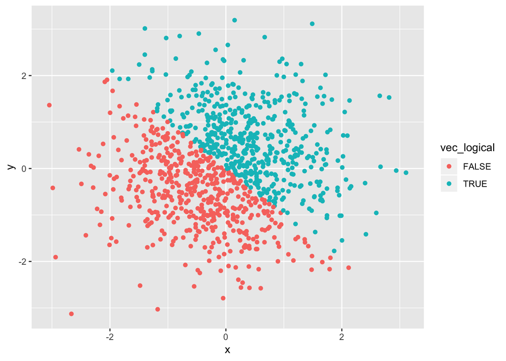

```r
ggplot(problem_2_df, aes(x = x, y = y, color = vec_logical)) + geom_point()
```

## Creating a scatterplot of y vs x with colored points by the numeric variables

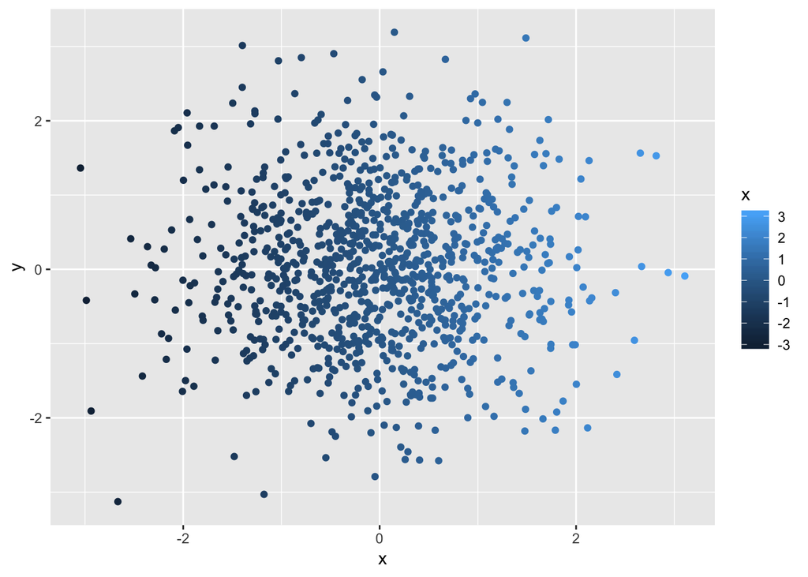

```r
ggplot(problem_2_df, aes(x = x, y = y, color = x, color = y)) + geom_point()
```

The color scale in this graph is a spectrum of the color blue instead of a distict color for a dichotomous measure.

## Creating a scatterplot of y vs x with colored points by the factor variables

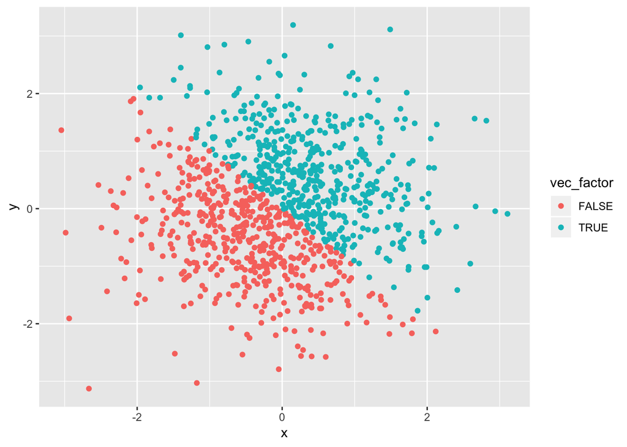

```r
ggplot(problem_2_df, aes(x = x, y = y, color = vec_factor)) + geom_point()
```

The color scale in this graph is the same as the first scatterplot. There is a distict color given for when the logical variable is true and false.